# Ergosup–Projet_Analysis_of_Patents

# Introduction d’entreprise: Ergosup

Maintenant, la production d’hydrogène énergie provient principalement de combustibles chimiques, mais l’utilisation de combustibles chimiques pour produire de l’hydrogène énergie entraînera de nombreuses émissions de carbone, ce qui augmentera la charge sur l’environnement.

La société Ergosup que nous avons étudiée dans ce projet est une entreprise start-up dédiée à la recherche sur les énergies propres. En 2019, elle a levé 11 millions d’euros pour l’industrialisation et son procédé breveté: la production et le stockage sans hydrocarbures. Son principal objectif de recherche est la conversion de l’énergie électrique en énergie hydrogène. Les principaux domaines de recherche sont dans les domaines de l’énergie électrique, de la chimie et de la fabrication mécanique.

# Les données(Préparation et traitement)

Nous avons téléchargé les résultats des 6 questions que nous avons fait pendant la dernier scéance sur la base de données Patstats. Et pour faciliter les études statistiques, nous avons redécodé quelques variables que nous aurons besoin dans les tables des résultat en format “factor”.

## Données de question 1

Après le traitement des données, toutes les variables sont en catétorielle.

Les variables sont :

1.”appln_id”: Les identifications qui sont déposé par entreprise ‘Ergosup’.

2.”appln_auth”: Les bureaux où ces brevets sont déposés.

3.”appln_filing_year”: L’années quand les brevets sont déposés dans les bureaux.

4.”docdb_family_id”: L’identification des familles des brevets qui sont déposés par Ergosup.

5.”granted”: Si les brevets sont accordés ou non; N: non accordé, Y : accordé.

## Données de question 2a et 2b

Après le traitement des données, toutes les variables sont en catétorielle.

2a)

1.”appln_id”: Identification des brevets.

2.”cpc_class_symbol”: La classe CPC de brevets.

2b)

1. “appln_id”: Identification de brevets.

2.”Ipc_class_symbol”: La classe IPC de brevets.

## Données de question 3a et 3b

3a) f_citn: en numérique; les autres variables sont en catécorielle.

1.”appln_id”: Identification de brevet.

2.”docdb_family_id”: Famille de brevet.

3.”f_citn”: Numéro de citation dans l’autre brevet quand le brevet est cité.

4.”citing_appln_id”: Indentification de brevet qui a cité le brevet de Ergosup.

5.”citing_family_id”: Identification de la famille de brevet qui cite le brevet de Ergosup.

6.”citing_appln_years”: L’année où le brevet de Ergosup est cité.

3b) f_citn: en numérique: les autres variabels sont en catécorielle.

1.”appln_id”: Identification de brevet.

2.”docdb_family_id”: Famille de brevet.

3.”f_citn”: Numéro de citation dans l’autre brevet quand le brevet est cité.

4.”citing_ipc4”: La classe de IPC du brevet qui a cité le brevet de Ergosup.

5.”citing_family_id”: Identification de la famille de brevet qui cite le brevet de Ergosup.

## Données de question 4

fee_renewal_year:en numérique, les autres variables sont en catécorielle.

1.”appln_id”: Identification de brevet.

2.”event_code”: Si le brevet est renouvellé; PLFP: Il est renouvellé, ST: Sinon.

3.”event_publn_year”: L’année de renouvellement.

4.”fee_renewal_year”: Le nombre de fois de renouvellement de ce brevet.

# Question 1: Liste des brevets deposés par la firme “Ergosup”

## La situation d’innovation.

Nous trouvons que cette entreprise a demarré ces activités d’innovations depuis 2010, mais leS nombre de brevets déposés sont plus important dans les années 2010,2018 et 2019,er pendant la période de 2013 à 2017, sauf que 0 brevet est déposé à 2017, chaque année Ergosup dépose au moins un brevet.

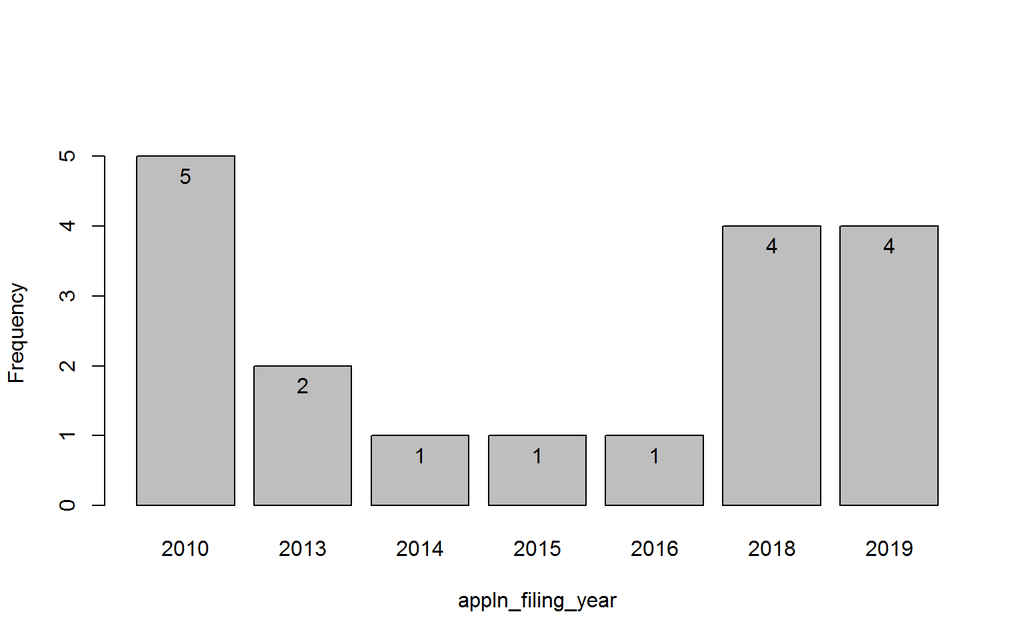

## Ces brevets sont déposés où?

Cette entreprise a deposé 18 brevets aux 7 differents bureaux de brevets. Ils sont:

```
      CA:Bureau de brevet canadien,

      EP:Bureau de brevet Union Européenne,

      ES:Bureau de brevet espagnol,

      FR:Bureau de brevet de la france,

      US:Bureau de brevet aux État-Unis,

      WO:Bureau de brevet international.
```

|  | Bureau de brevets | Nombre de déposition |
| --- | --- | --- |
| 1 | CA | 1 |
| 2 | EP | 1 |
| 3 | ES | 1 |
| 4 | FR | 7 |
| 5 | KR | 1 |
| 6 | US | 1 |
| 7 | WO | 6 |

Nous pouvons conclure qu’elle dépose ses brevets principalement dans les bureaux de brevet international(6 brevets,33% de ses brevets) et le bureau de brevet de la france(7 brevets, 39% de ces brevets), et nous pouvons aussi conclure que Canada, Espagne, Korée, États-Unis peuvent-être devenir ces marchés principaux aux étrangers, c’est è dire que les technologies ou les produits de Ergosup vont être vendue principalement dans ces pays. Mais un point intéressant est que l’entreprise n’a pas déposé beaucoup de ces brevets dans le bureau de brevet de union européenne.

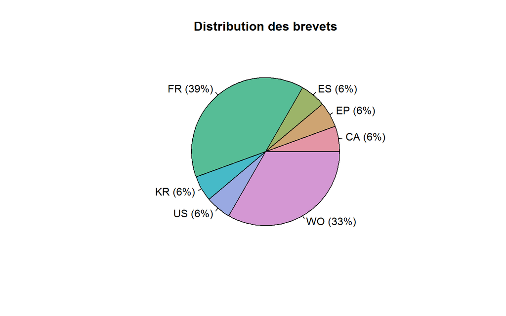

Il y a plus d’un moitié(11) de ces brevets n’est pas encore accordé par les bureaux où ils sont déposés, et pendant nous regardons les situations des brevets qui sont déposé dans les 2 bureaux de brevets de la france et international, nous trouvons qu’il n’y a que 2 brevets(2/7) sont accordés par le bureau de brevets de la france et 100%(6/6) de brevets ne sont pas encore accordés par le bureau de brevets internationnal. Pour les autres brevets, ils sont tous accordés par les bureaux où il sont déposés.

|  | Situation d’accord | Nbre |
| --- | --- | --- |
| 1 | N | 11 |
| 2 | Y | 7 |

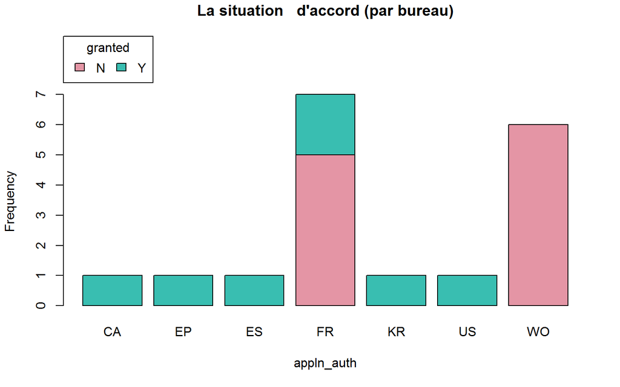

## La situation de famille de ces brevets

|  | Identification | Nbre |
| --- | --- | --- |
| 1 | 41796602 | 5 |
| 2 | 48521113 | 2 |
| 3 | 52423730 | 3 |
| 4 | 63143212 | 2 |
| 5 | 63143213 | 2 |
| 6 | 63896235 | 2 |
| 7 | 63896236 | 2 |

# Question 2 Classes technologique associées a ces brevets : IPC puis CPC

## Ques-ce que c’est, CPC et IPC?

### CPC(Cooperative Patent Classification):

La classification coopérative des brevets est un système de classification conjoint développé par l’Office européen des brevets (OEB) et l’Office des brevets et des marques des États-Unis (USPTO). La plupart du système de classification est basé sur le système de classification des brevets européens (ECLA/ICO ). ) En tant que base, combiné avec la classification des brevets des États-Unis (USPC), et compatible avec la classification internationale des brevets (IPC) existante; son objectif est de développer un système de classification unifié et général pour les publications de brevets.

CPC a actuellement des parties A - H et Y, A - H correspond à 8 parties de l’IPC; la partie Y nouvellement ajoutée, dont une partie correspond aux domaines technologiques nouvellement ajoutés, tels que la technologie Y02 pour améliorer le changement climatique, la technologie de réseau intelligent Y04; et une partie correspond à la coupe transversale des collections d’art de référence croisée de l’USPC.

### IPC(International Patent Classification):

La Classification Internationale des Brevets a été compilée conformément à “Arrangement de Strasbourg sur la classification internationale des brevets” signé en 1971 et est entrée en vigueur le 7 octobre 1975. C’est actuellement l’outil utilisé au niveau international pour la classification et la récupération des documents de brevet. En 2012, l’accord comptait 61 États membres.

## Question 2a CPC

|  | CPC | Nbre |
| --- | --- | --- |
| 1 | C01B | 5 |
| 2 | C25B | 12 |
| 3 | C25C | 4 |
| 4 | F04B | 2 |
| 5 | H01M | 14 |
| 6 | Y02E | 18 |
| 7 | Y02P | 7 |

Nous trouvons que les cpc de ces brevets se situent dans les domaines: C,F,H,Y.

Les brevets qu’elle a déposé dans le domaine de la chimie ; la métallurgie (C) sont principalement dédiés à l’étude de l’électrolyse des composés métalliques et non métalliques (nous savons que la réaction chimique de l’électrolyse peut convertir l’énergie électrique en énergie chimique), et ses applications dans le domaine de l’ingénierie mécanique (F) sont principalement dédiés à la recherche d’équipements de transport de liquide. Et ses recherches dans le domaine de l’énergie électrique s’orientent vers les batteries chimiques (convertissant l’énergie chimique en énergie électrique). Et dans le domaine Y, elle a également déposé des brevet dédiés à la réduction des émissions de gaz à effet de serre.

Parmis ces brevets, nous trouvons que la plus part de ces brevets sont dans les 3 classes: C25B, H01M, Y02E.

Ce sont les informations détailés sur les 4 classes CPC des brevets de Ergosup.(Nous pouvons trouvés les informations [ICI](https://worldwide.espacenet.com/classification?locale=en_EP) )

*C: CHIMIE ; MÉTALLURGIE*

*C01B*: ÉLÉMENTS NON MÉTALLIQUES ; COMPOSÉS DE CEUX-CI; MÉTALLODES OU COMPOSÉS DE CEUX- CI NON VISÉS PAR LA SOUS- CLASSE C01C

*C25B*: PROCEDES ELECTROLYTIQUES OU ELECTROPHORETIQUES POUR LA PRODUCTION DE COMPOSES OU DE NON-METAUX ; APPAREIL À CET APPAREIL ( protection anodique ou cathodique C23F13/00 ; croissance monocristalline C30B )

*C25C*: PROCÉDÉS DE PRODUCTION ÉLECTROLYTIQUE, DE RÉCUPÉRATION OU D’AFFINAGE DES MÉTAUX ; APPAREIL À CET APPAREIL

*F: INGÉNIERIE MÉCANIQUE ; ECLAIRAGE ; CHAUFFAGE ; ARMES ; SAUTAGE*

*F04B*: MACHINES A DEPLACEMENT POSITIF POUR LIQUIDES ; POMPES ( machines à liquides, ou pompes, à piston rotatif ou oscillant F04C ; pompes non volumétriques F04D ; pompage de fluide par contact direct d’un autre fluide ou en utilisant l’inertie du fluide à pomper F04F )

*H: ÉLECTRICITÉ*

*H01M*: PROCEDES OU MOYENS, p.ex. BATTERIES, POUR LA CONVERSION DIRECTE DE L’ENERGIE CHIMIQUE EN ENERGIE ELECTRIQUE

*Y: SECTIONS DE L’IPC ; SUJETS TECHNIQUES COUVERTS PAR LES ANCIENNES COLLECTIONS D’ART DE RÉFÉRENCE USPC [XRAC] ET RÉGIME*

*Y02E*: RÉDUCTION DES ÉMISSIONS DE GAZ À EFFET DE SERRE [GES] LIÉES À LA PRODUCTION, AU TRANSPORT OU À LA DISTRIBUTION D’ÉNERGIE

*Y02p*: TECHNOLOGIES D’ATTÉNUATION DU CHANGEMENT CLIMATIQUE DANS LA PRODUCTION OU LA TRANSFORMATION DES MARCHANDISES

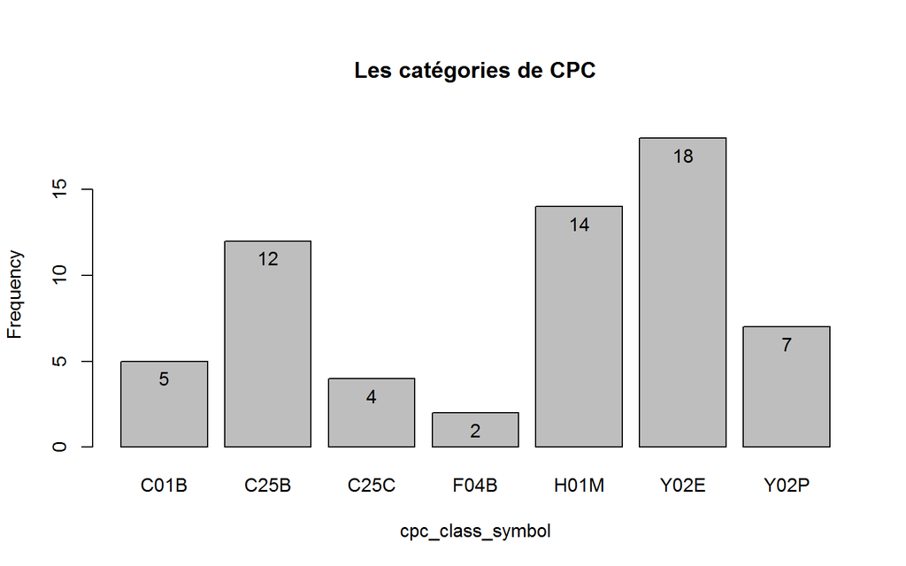

## Question 2b IPC

|  | Ipc | Nbre |
| --- | --- | --- |
| 1 | B01D | 1 |
| 2 | C01B | 9 |
| 3 | C25B | 13 |
| 4 | C25C | 2 |
| 5 | C25D | 1 |
| 6 | F25B | 1 |
| 7 | H01M | 16 |

Parmis les classe IPC, nous trouvons que la plupart de ces brevets sont dans les 2 classes: C025 et H01M.

Ce sont les informations détailés sur les 4 classes IPC des brevets de Ergosup.(Nous pouvons trouvés les informations ICI

*C: CHIMIE ; MÉTALLURGIE*

*c01b*: ÉLÉMENTS NON MÉTALLIQUES ; COMPOSÉS DE CEUX-CI; MÉTALLODES OU COMPOSÉS DE CEUX- CI NON VISÉS PAR LA SOUS- CLASSE C01C

*c25b*: PROCEDES ELECTROLYTIQUES OU ELECTROPHORETIQUES POUR LA PRODUCTION DE COMPOSES OU DE NON-METAUX APPAREIL À CET APPAREIL ( protection anodique ou cathodique C23F13/00 ; croissance monocristalline C30B )

*C25C*: PROCÉDÉS DE PRODUCTION ÉLECTROLYTIQUE, DE RÉCUPÉRATION OU D’AFFINAGE DES MÉTAUX ; APPAREIL À CET APPAREIL

*H: ÉLECTRICITÉ*

*H01M*: PROCEDES OU MOYENS, p.ex. BATTERIES, POUR LA CONVERSION DIRECTE DE L’ENERGIE CHIMIQUE EN ENERGIE ELECTRIQUE *Y: SECTIONS DE L’IPC ; SUJETS TECHNIQUES COUVERTS PAR LES ANCIENNES COLLECTIONS D’ART DE RÉFÉRENCE USPC [XRAC] ET RÉGIME*

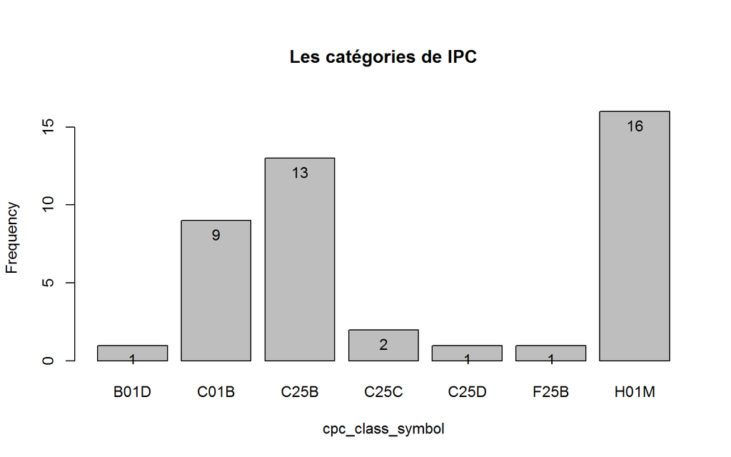

## Conclusion

D’après les informations retours du CPC et IPC de cette entreprise, nous pouvons savoir que ses brevets sont principalement dans les domaines de la chimie, des machines et de l’électricité. Il est dédié à la recherche mécanique qui convertit l’énergie chimique en énergie électrique.

Nous trouvons aussi que l’entreprise mène également des recherches plus approfondies dans le domaine de l’énergie propre et de la réduction des émissions de Co2.

# Question 3: Citations recues par ces brevets : Liste simple puis ajouter les informations sur classes technologique des brevets citants

## Question 3a

c’est le tableau qui présente les nombre de fois d’être cité des brevets qui sont déposé par Ergosup, la colonne n_citn nous montre le nombre brut d’être cité et n_citn c’est le nombre nette en éliminant les auto-citations des brevets. Nous trouvons qu’il y a 5 brevets sont cités parmis tous ses brevets, mais d’après le nombre nette, nous trouvons que les brevets qui ont “363592032”,“365969867”comme identification sont plus souvent être cité pas les autres inventeurs, mais les autres brevets sont créées plustôt pour ses propres recherches(cité par Ergosup lui-même).

|  | Identification | n_citn | n_citn2 |
| --- | --- | --- | --- |
| 1 | 363592032 | 13 | 12.00 |
| 2 | 365969867 | 5 | 4.00 |
| 3 | 406913233 | 1 | 0.00 |
| 4 | 426026395 | 1 | 0.00 |
| 5 | 468102108 | 2 | 1.00 |

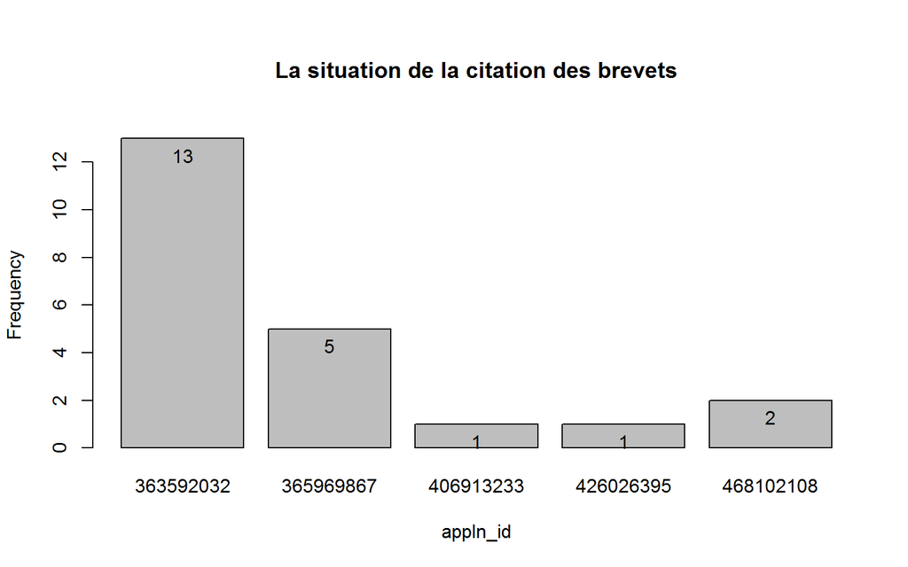

Les 2 brevets qui sont citéS le plus de fois par les autres inventeurs sont déposé aux états-unis et korée.

|  | appln_id | appln_auth |
| --- | --- | --- |
| 12 | 363592032 | US |
| 15 | 365969867 | KR |

|  | appln_id | cpc_class_symbol |
| --- | --- | --- |
| 2 | 365969867 | H01M |
| 6 | 363592032 | H01M |
| 9 | 365969867 | Y02E |
| 19 | 363592032 | Y02E |
| 50 | 365969867 | C25B |
| 53 | 363592032 | C01B |
| 55 | 363592032 | C25B |
| 56 | 365969867 | C01B |

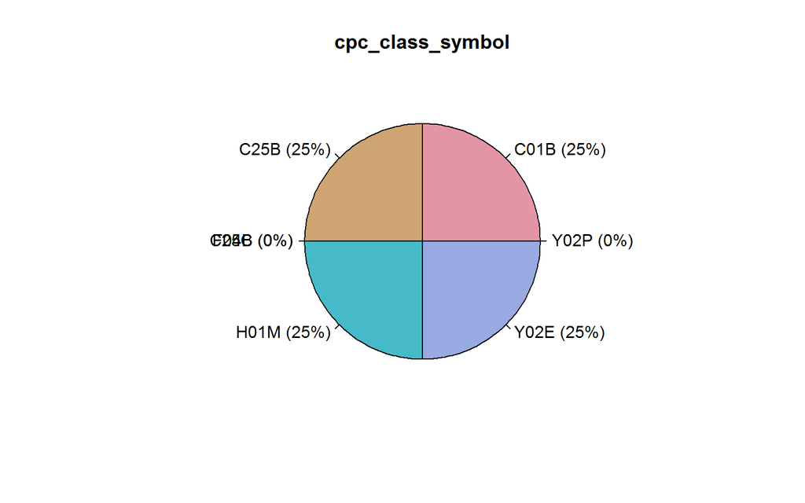

Les IPC des 2 brevets sont dans les classe: C25B, C01B, C25D et H01M.

|  | appln_id | Ipc_class_symbol |
| --- | --- | --- |
| 21 | 365969867 | C25B |
| 25 | 365969867 | C01B |
| 28 | 363592032 | C25D |
| 34 | 365969867 | H01M |
| 36 | 363592032 | H01M |

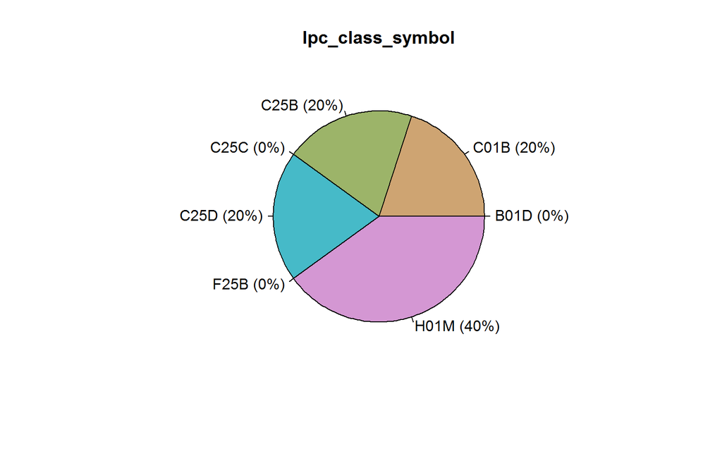

Nous trouvons que ses brevets sont cités frequement dans l’année 2015, il y a 41% de citations a lieu dans cette année, et quand même il n’a pas déposé beaucoup de brevets pendant les années entre 2014 et 2017, mais ça ne diminue pas le nombre de citations, cette phénomène nous affiche que la qualité de ces brevets sont très bien et aussi qu’ils peuvent donner des très fort influences positives dans les domaines des brevets.

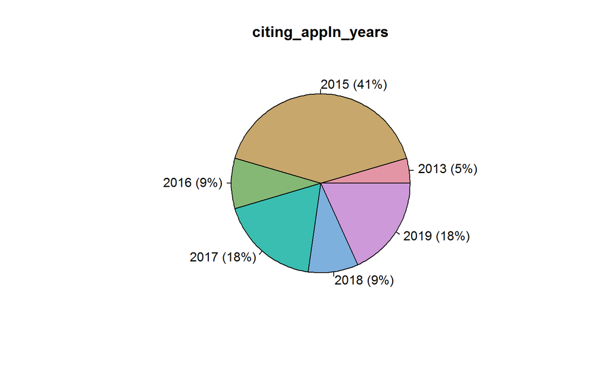

|  | docdb_family_id | Nbre_famille_id | n_citn3 |
| --- | --- | --- | --- |
| 1 | 41796602 | 18 | 17.00 |
| 2 | 48521113 | 1 | 0.00 |
| 3 | 52423730 | 3 | 2.00 |

## Question 3b

Nous voulons calculé l’indice de generalité d’un brevet i,

|  | cting_ipc4 | Nbre_cting_ipc4 | Sij | Sij_carée |
| --- | --- | --- | --- | --- |
| 1 | C01B | 5 | 0.12 | 0.02 |
| 2 | C25B | 8 | 0.20 | 0.04 |
| 3 | C25D | 9 | 0.22 | 0.05 |
| 4 | H01M | 18 | 0.45 | 0.20 |

Indice de généralité d’un brevet =
$$1 - \sum{(Sij)}^{2}$$
Indice :

```
## [1] 0.69125
```

# Question 4: La situation de renouvellement des brevets

|  | 2016 | 2017 | 2018 | 2019 |
| --- | --- | --- | --- | --- |
| PLFP | 4 | 3 | 6 | 5 |
| ST | 1 | 0 | 0 | 0 |

Nous pouvons savoir la situation de renouvellement des brevets par le tableau. D’après nos resultats, presque tous des brevets ont été renouvelés au moins une fois. L’entreprise a renouvelé plusieurs brevets en 2019. Par contre, il y’a qu’un seul brevet qu’il n’a pas fait sa demande de renouvellement et c’est en 2016.

# Références bibliographiques

http://www.frenchcleantech.com/companies.html?page=1

https://worldwide.espacenet.com/advancedSearch?locale=fr_EP.

https://ipcpub.wipo.int/?notion=scheme&version=20190101&symbol=none&menulang=fr&lang=fr&viewmode=f&fipcpc=no&showdeleted=yes&indexes=no&headings=yes&notes=yes&direction=o2n&initial=A&cwid=none&tree=no&searchmode=smart

https://worldwide.espacenet.com/classification?locale=en_EP